# Hitters Notebook

The hitters dataset consists of 322 observations of 21 variables with the following information - X (name), AtBat, Hits, HmRun (home runs), Runs, RBI, Walks, Years, CAtBat, CHits, CHmRun, CRuns, CRBI, CWalks, League, Division, PutOuts, Assists, Errors, Salary, New League. Here League, Division and NewLeagues are factor variabes with 2 categories. We drop rows with missing entries and are left with 263 observations.

```r
hitters <- read.csv("hitters.csv")
str(hitters)
```

```
'data.frame':   322 obs. of  21 variables:
 $ X        : Factor w/ 322 levels "-Al Newman","-Alan Ashby",..: 12 2 7 8 10 6 1 14 11 9 ...
 $ AtBat    : int  293 315 479 496 321 594 185 298 323 401 ...
 $ Hits     : int  66 81 130 141 87 169 37 73 81 92 ...
 $ HmRun    : int  1 7 18 20 10 4 1 0 6 17 ...
 $ Runs     : int  30 24 66 65 39 74 23 24 26 49 ...
 $ RBI      : int  29 38 72 78 42 51 8 24 32 66 ...
 $ Walks    : int  14 39 76 37 30 35 21 7 8 65 ...
 $ Years    : int  1 14 3 11 2 11 2 3 2 13 ...
 $ CAtBat   : int  293 3449 1624 5628 396 4408 214 509 341 5206 ...
 $ CHits    : int  66 835 457 1575 101 1133 42 108 86 1332 ...
 $ CHmRun   : int  1 69 63 225 12 19 1 0 6 253 ...
 $ CRuns    : int  30 321 224 828 48 501 30 41 32 784 ...
 $ CRBI     : int  29 414 266 838 46 336 9 37 34 890 ...
 $ CWalks   : int  14 375 263 354 33 194 24 12 8 866 ...
 $ League   : Factor w/ 2 levels "A","N": 1 2 1 2 2 1 2 1 2 1 ...
 $ Division : Factor w/ 2 levels "E","W": 1 2 2 1 1 2 1 2 2 1 ...
 $ PutOuts  : int  446 632 880 200 805 282 76 121 143 0 ...
 $ Assists  : int  33 43 82 11 40 421 127 283 290 0 ...
 $ Errors   : int  20 10 14 3 4 25 7 9 19 0 ...
 $ Salary   : num  NA 475 480 500 91.5 750 70 100 75 1100 ...
 $ NewLeague: Factor w/ 2 levels "A","N": 1 2 1 2 2 1 1 1 2 1 ...
```

```r
hitters<-na.omit(hitters)
str(hitters)
```

```
'data.frame':   263 obs. of  21 variables:
 $ X        : Factor w/ 322 levels "-Al Newman","-Alan Ashby",..: 2 7 8 10 6 1 14 11 9 3 ...
 $ AtBat    : int  315 479 496 321 594 185 298 323 401 574 ...
 $ Hits     : int  81 130 141 87 169 37 73 81 92 159 ...
 $ HmRun    : int  7 18 20 10 4 1 0 6 17 21 ...
 $ Runs     : int  24 66 65 39 74 23 24 26 49 107 ...
 $ RBI      : int  38 72 78 42 51 8 24 32 66 75 ...
 $ Walks    : int  39 76 37 30 35 21 7 8 65 59 ...
 $ Years    : int  14 3 11 2 11 2 3 2 13 10 ...
 $ CAtBat   : int  3449 1624 5628 396 4408 214 509 341 5206 4631 ...
 $ CHits    : int  835 457 1575 101 1133 42 108 86 1332 1300 ...
 $ CHmRun   : int  69 63 225 12 19 1 0 6 253 90 ...
 $ CRuns    : int  321 224 828 48 501 30 41 32 784 702 ...
 $ CRBI     : int  414 266 838 46 336 9 37 34 890 504 ...
 $ CWalks   : int  375 263 354 33 194 24 12 8 866 488 ...
 $ League   : Factor w/ 2 levels "A","N": 2 1 2 2 1 2 1 2 1 1 ...
 $ Division : Factor w/ 2 levels "E","W": 2 2 1 1 2 1 2 2 1 1 ...
 $ PutOuts  : int  632 880 200 805 282 76 121 143 0 238 ...
 $ Assists  : int  43 82 11 40 421 127 283 290 0 445 ...
 $ Errors   : int  10 14 3 4 25 7 9 19 0 22 ...
 $ Salary   : num  475 480 500 91.5 750 ...
 $ NewLeague: Factor w/ 2 levels "A","N": 2 1 2 2 1 1 1 2 1 1 ...
 - attr(*, "na.action")= 'omit' Named int  1 16 19 23 31 33 37 39 40 42 ...
  ..- attr(*, "names")= chr  "1" "16" "19" "23" ...
```

The leaps package in R does subset selection with the regsubsets function. By default, the maximum number of subsets, this function uses is 8. We extend this to do a complete subset selection by changing the default value of nvmax argument in this function. Note that CRBI is in the model with 1 to 6 variables but not in the model with 7 and 8 variables.

```r
#install.packages("leaps")
library(leaps)
?regsubsets
hitters <- hitters[,2:21]
model1 <- regsubsets(Salary~.,hitters)
summary(model1)
```

```
Subset selection object
Call: regsubsets.formula(Salary ~ ., hitters)
19 Variables  (and intercept)
           Forced in Forced out
AtBat          FALSE      FALSE
Hits           FALSE      FALSE
HmRun          FALSE      FALSE
Runs           FALSE      FALSE
RBI            FALSE      FALSE
Walks          FALSE      FALSE
Years          FALSE      FALSE
CAtBat         FALSE      FALSE
CHits          FALSE      FALSE
CHmRun         FALSE      FALSE
CRuns          FALSE      FALSE
CRBI           FALSE      FALSE
CWalks         FALSE      FALSE
LeagueN        FALSE      FALSE
DivisionW      FALSE      FALSE
PutOuts        FALSE      FALSE
Assists        FALSE      FALSE
Errors         FALSE      FALSE
NewLeagueN     FALSE      FALSE
1 subsets of each size up to 8
Selection Algorithm: exhaustive
         AtBat Hits HmRun Runs RBI Walks Years CAtBat CHits CHmRun CRuns CRBI CWalks LeagueN
1  ( 1 ) " "   " "  " "   " "  " " " "   " "   " "    " "   " "    " "   "*"  " "    " "
2  ( 1 ) " "   "*"  " "   " "  " " " "   " "   " "    " "   " "    " "   "*"  " "    " "
3  ( 1 ) " "   "*"  " "   " "  " " " "   " "   " "    " "   " "    " "   "*"  " "    " "
4  ( 1 ) " "   "*"  " "   " "  " " " "   " "   " "    " "   " "    " "   "*"  " "    " "
5  ( 1 ) "*"   "*"  " "   " "  " " " "   " "   " "    " "   " "    " "   "*"  " "    " "
6  ( 1 ) "*"   "*"  " "   " "  " " "*"   " "   " "    " "   " "    " "   "*"  " "    " "
7  ( 1 ) " "   "*"  " "   " "  " " "*"   " "   "*"    "*"   "*"    " "   " "  " "    " "
8  ( 1 ) "*"   "*"  " "   " "  " " "*"   " "   " "    " "   "*"    "*"   " "  "*"    " "
         DivisionW PutOuts Assists Errors NewLeagueN
1  ( 1 ) " "       " "     " "     " "    " "
2  ( 1 ) " "       " "     " "     " "    " "
3  ( 1 ) " "       "*"     " "     " "    " "
4  ( 1 ) "*"       "*"     " "     " "    " "
5  ( 1 ) "*"       "*"     " "     " "    " "
6  ( 1 ) "*"       "*"     " "     " "    " "
7  ( 1 ) "*"       "*"     " "     " "    " "
8  ( 1 ) "*"       "*"     " "     " "    " "
```

```r
model2<-regsubsets(Salary~.,hitters,nvmax=19)
summary(model2)
```

```
Subset selection object
Call: regsubsets.formula(Salary ~ ., hitters, nvmax = 19)
19 Variables  (and intercept)
           Forced in Forced out
AtBat          FALSE      FALSE
Hits           FALSE      FALSE
HmRun          FALSE      FALSE
Runs           FALSE      FALSE
RBI            FALSE      FALSE
Walks          FALSE      FALSE
Years          FALSE      FALSE
CAtBat         FALSE      FALSE
CHits          FALSE      FALSE
CHmRun         FALSE      FALSE
CRuns          FALSE      FALSE
CRBI           FALSE      FALSE
CWalks         FALSE      FALSE
LeagueN        FALSE      FALSE
DivisionW      FALSE      FALSE
PutOuts        FALSE      FALSE
Assists        FALSE      FALSE
Errors         FALSE      FALSE
NewLeagueN     FALSE      FALSE
1 subsets of each size up to 19
Selection Algorithm: exhaustive
          AtBat Hits HmRun Runs RBI Walks Years CAtBat CHits CHmRun CRuns CRBI CWalks LeagueN
1  ( 1 )  " "   " "  " "   " "  " " " "   " "   " "    " "   " "    " "   "*"  " "    " "
2  ( 1 )  " "   "*"  " "   " "  " " " "   " "   " "    " "   " "    " "   "*"  " "    " "
3  ( 1 )  " "   "*"  " "   " "  " " " "   " "   " "    " "   " "    " "   "*"  " "    " "
4  ( 1 )  " "   "*"  " "   " "  " " " "   " "   " "    " "   " "    " "   "*"  " "    " "
5  ( 1 )  "*"   "*"  " "   " "  " " " "   " "   " "    " "   " "    " "   "*"  " "    " "
6  ( 1 )  "*"   "*"  " "   " "  " " "*"   " "   " "    " "   " "    " "   "*"  " "    " "
7  ( 1 )  " "   "*"  " "   " "  " " "*"   " "   "*"    "*"   "*"    " "   " "  " "    " "
8  ( 1 )  "*"   "*"  " "   " "  " " "*"   " "   " "    " "   "*"    "*"   " "  "*"    " "
9  ( 1 )  "*"   "*"  " "   " "  " " "*"   " "   "*"    " "   " "    "*"   "*"  "*"    " "
10  ( 1 ) "*"   "*"  " "   " "  " " "*"   " "   "*"    " "   " "    "*"   "*"  "*"    " "
11  ( 1 ) "*"   "*"  " "   " "  " " "*"   " "   "*"    " "   " "    "*"   "*"  "*"    "*"
12  ( 1 ) "*"   "*"  " "   "*"  " " "*"   " "   "*"    " "   " "    "*"   "*"  "*"    "*"
13  ( 1 ) "*"   "*"  " "   "*"  " " "*"   " "   "*"    " "   " "    "*"   "*"  "*"    "*"
14  ( 1 ) "*"   "*"  "*"   "*"  " " "*"   " "   "*"    " "   " "    "*"   "*"  "*"    "*"
```

[output cut: 10 more lines]

```
5  ( 1 )  "*"       "*"     " "     " "    " "
6  ( 1 )  "*"       "*"     " "     " "    " "
7  ( 1 )  "*"       "*"     " "     " "    " "
8  ( 1 )  "*"       "*"     " "     " "    " "
9  ( 1 )  "*"       "*"     " "     " "    " "
10  ( 1 ) "*"       "*"     "*"     " "    " "
11  ( 1 ) "*"       "*"     "*"     " "    " "
12  ( 1 ) "*"       "*"     "*"     " "    " "
13  ( 1 ) "*"       "*"     "*"     "*"    " "
14  ( 1 ) "*"       "*"     "*"     "*"    " "
15  ( 1 ) "*"       "*"     "*"     "*"    " "
16  ( 1 ) "*"       "*"     "*"     "*"    " "
17  ( 1 ) "*"       "*"     "*"     "*"    "*"
18  ( 1 ) "*"       "*"     "*"     "*"    "*"
19  ( 1 ) "*"       "*"     "*"     "*"    "*"
```

```r
names(summary(model2))
```

```
[1] "which"  "rsq"    "rss"    "adjr2"  "cp"     "bic"    "outmat" "obj"
```

```r
summary(model2)$rsq
```

```
 [1] 0.3214501 0.4252237 0.4514294 0.4754067 0.4908036 0.5087146 0.5141227 0.5285569 0.5346124
[10] 0.5404950 0.5426153 0.5436302 0.5444570 0.5452164 0.5454692 0.5457656 0.5459518 0.5460945
[19] 0.5461159
```

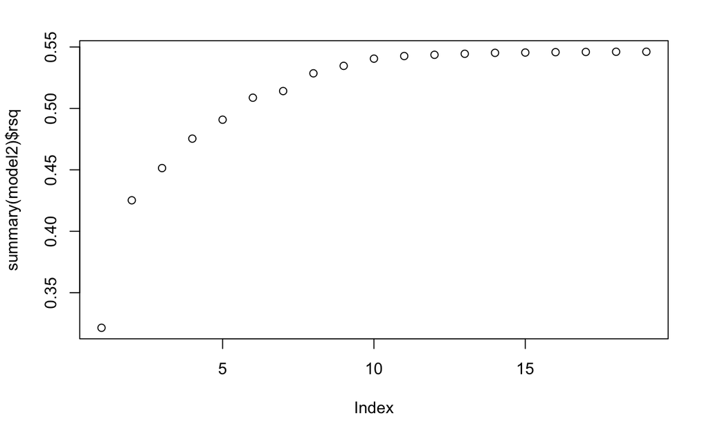

```r
plot(summary(model2)$rsq)
```

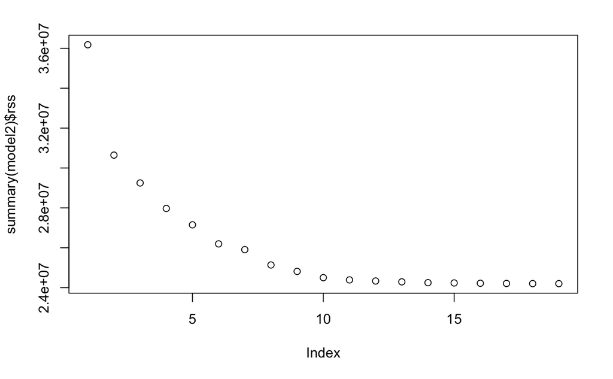

```r
plot(summary(model2)$rss)
```

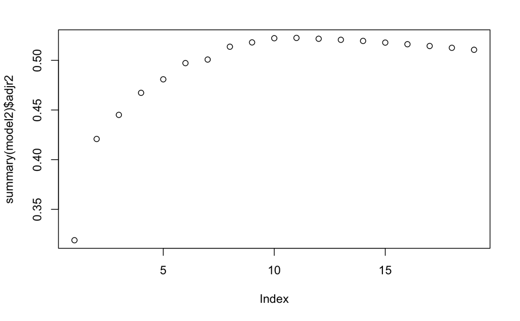

```r
plot(summary(model2)$adjr2)
```

```r
which.max(summary(model2)$adjr2)
```

```
[1] 11
```

```r
coef(model2,11)
```

```
 (Intercept)        AtBat         Hits        Walks       CAtBat        CRuns         CRBI
 135.7512195   -2.1277482    6.9236994    5.6202755   -0.1389914    1.4553310    0.7852528
      CWalks      LeagueN    DivisionW      PutOuts      Assists
  -0.8228559   43.1116152 -111.1460252    0.2894087    0.2688277
```

The figures indicate that R-squared increase as the number of variables in the subset increases and likewise the residual sum of squared (sum of squared errors) decreases as the size of the subsets increases. On the other hand the adjusted R-squared increases first and then decreases.

Forward stepwise selection: In this example, the best model identified by the forward stepwise selection is the same as that obtained by the best subset selection. It is also possible to run this algorithm using a backward method where you drop variables one a time rather add. In general, the solutions from these two methods can be different.

```r
model3<-regsubsets(Salary~.,data=hitters,nvmax=19,method="forward")
which.max(summary(model3)$adjr2)
```

```
[1] 11
```

```r
coef(model3,11)
```

```
 (Intercept)        AtBat         Hits        Walks       CAtBat        CRuns         CRBI
 135.7512195   -2.1277482    6.9236994    5.6202755   -0.1389914    1.4553310    0.7852528
      CWalks      LeagueN    DivisionW      PutOuts      Assists
  -0.8228559   43.1116152 -111.1460252    0.2894087    0.2688277
```

```r
summary(model2)$adjr2-summary(model3)$adjr2
```

```
 [1] 3.330669e-16 1.110223e-16 0.000000e+00 0.000000e+00 1.110223e-16 0.000000e+00 9.185854e-04
 [8] 4.314850e-04 1.110223e-16 1.110223e-16 1.110223e-16 0.000000e+00 0.000000e+00 2.220446e-16
[15] 1.110223e-16 0.000000e+00 0.000000e+00 0.000000e+00 0.000000e+00
```

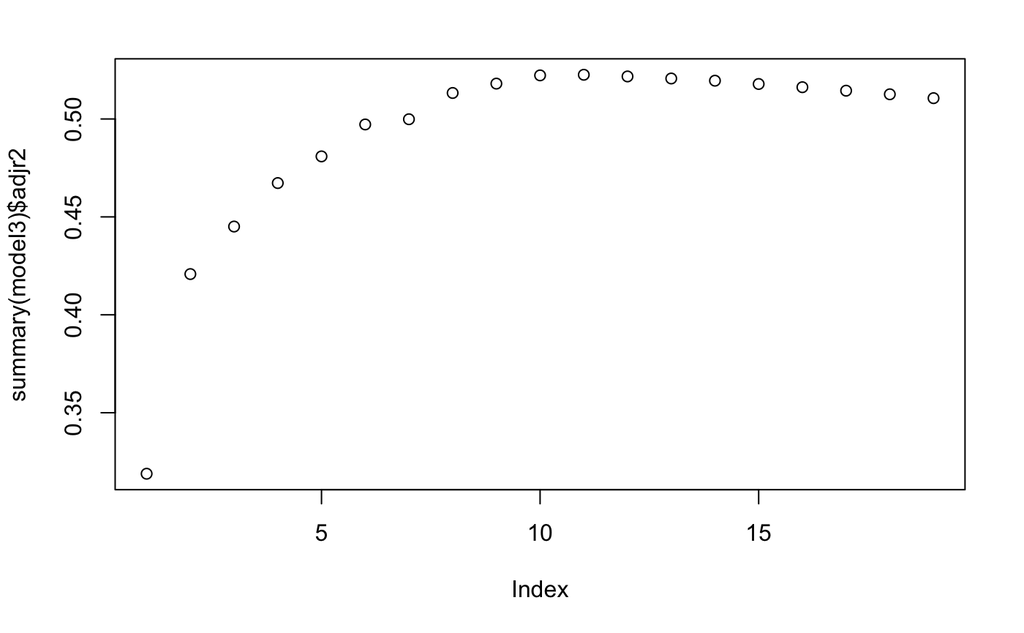

```r
plot(summary(model3)$adjr2)
```

LASSO: The generalized linear model with penalized maximum likelihood package glmnet in R implements the LASSO method. To run the glmnet() function, we need to pass in the arguments as X (input matrix), y (output vector), rather than the y~X format that we used thus far. The model.matrix() function produces a matrix corresponding to the 19 predictors and the intercept and helps transform qualitative variables into dummy quantitative variables. This is important since glmnet() works only with quantitative variabes.

```r
#install.packages("glmnet")
library(glmnet)
X <- model.matrix(Salary~.,hitters)
y <- hitters$Salary
str(X)
```

```
 num [1:263, 1:20] 1 1 1 1 1 1 1 1 1 1 ...
 - attr(*, "dimnames")=List of 2
  ..$ : chr [1:263] "2" "3" "4" "5" ...
  ..$ : chr [1:20] "(Intercept)" "AtBat" "Hits" "HmRun" ...
 - attr(*, "assign")= int [1:20] 0 1 2 3 4 5 6 7 8 9 ...
 - attr(*, "contrasts")=List of 3
  ..$ League   : chr "contr.treatment"
  ..$ Division : chr "contr.treatment"
  ..$ NewLeague: chr "contr.treatment"
```

We now choose a range for the lambda parameters and create a training and test set. We then build the LASSO model on this data. The output from the model provides the Df (non of nonzeros), %Dev and Lambda values. The deviance measure is given as 2(loglike_sat - loglike), where loglike_sat is the log-likelihood for the saturated model (a model with a free parameter per observation). Null deviance is defined to be 2(loglike_sat - loglike(NULL)) where the NULL model refers to the intercept model only. The deviance ratio is dev.ratio=1-deviance/nulldev. As lambda decreases, the dev.ratio increases (more importance given to model fit than model complexity).

```r
grid<-10^seq(10,-2, length=100)
set.seed(1)
train <- sample(1:nrow(X),nrow(X)/2)
test <- -train
modellasso <- glmnet(X[train,],y[train],lambda=grid)
summary(modellasso)
```

```
          Length Class     Mode
a0         100   -none-    numeric
beta      2000   dgCMatrix S4
df         100   -none-    numeric
dim          2   -none-    numeric
lambda     100   -none-    numeric
dev.ratio  100   -none-    numeric
nulldev      1   -none-    numeric
npasses      1   -none-    numeric
jerr         1   -none-    numeric
offset       1   -none-    logical
call         4   -none-    call
nobs         1   -none-    numeric
```

```r
modellasso
```

```
Call:  glmnet(x = X[train, ], y = y[train], lambda = grid)

       Df   %Dev    Lambda
  [1,]  0 0.0000 1.000e+10
  [2,]  0 0.0000 7.565e+09
  [3,]  0 0.0000 5.722e+09
  [4,]  0 0.0000 4.329e+09
  [5,]  0 0.0000 3.275e+09
  [6,]  0 0.0000 2.477e+09
  [7,]  0 0.0000 1.874e+09
  [8,]  0 0.0000 1.417e+09
  [9,]  0 0.0000 1.072e+09
 [10,]  0 0.0000 8.111e+08
 [11,]  0 0.0000 6.136e+08
 [12,]  0 0.0000 4.642e+08
```

[output cut: 88 more lines]

```r
deviance(modellasso)
```

```
  [1] 27847946 27847946 27847946 27847946 27847946 27847946 27847946 27847946 27847946 27847946
 [11] 27847946 27847946 27847946 27847946 27847946 27847946 27847946 27847946 27847946 27847946
 [21] 27847946 27847946 27847946 27847946 27847946 27847946 27847946 27847946 27847946 27847946
 [31] 27847946 27847946 27847946 27847946 27847946 27847946 27847946 27847946 27847946 27847946
 [41] 27847946 27847946 27847946 27847946 27847946 27847946 27847946 27847946 27847946 27847946
 [51] 27847946 27847946 27847946 27847946 27847946 27847946 27847946 27847946 27847946 27847946
 [61] 27847946 27847946 27847946 27847946 24272481 21746207 19661359 18347154 17366967 16806088
 [71] 16485091 16239050 16093971 16007782 15836280 15708221 15330258 14861088 14473673 14172652
 [81] 13928191 13787741 13706876 13660299 13633432 13617860 13608871 13603606 13600532 13598677
 [91] 13597643 13597203 13596426 13596044 13595806 13595655 13595551 13595478 13595465 13595394
```

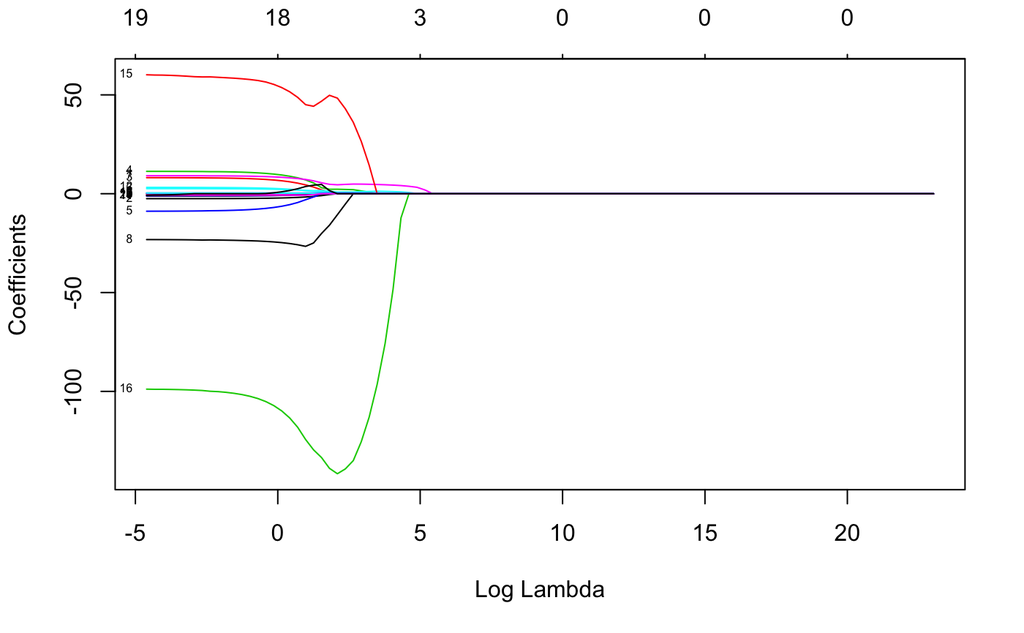

```r
plot(modellasso,xvar="lambda",label=TRUE)
```

We see from the plot that as lambda increases, many of the coefficients get close to zero. We can retrieve these coefficients as follows. Note that the number of non-zero coefficients does not change in a fully monotonic way, as lambda increases or decreases.

```r
modellasso$df
```

```
  [1]  0  0  0  0  0  0  0  0  0  0  0  0  0  0  0  0  0  0  0  0  0  0  0  0  0  0  0  0  0  0
 [31]  0  0  0  0  0  0  0  0  0  0  0  0  0  0  0  0  0  0  0  0  0  0  0  0  0  0  0  0  0  0
 [61]  0  0  0  0  2  3  4  5  5  5  5  7  7  8 10  9 13 15 16 17 17 17 18 18 18 17 17 17 17 17
 [91] 17 17 18 18 19 19 19 19 19 19
```

```r
modellasso$beta
```

```
20 x 100 sparse Matrix of class "dgCMatrix"
```

```
   [[ suppressing 41 column names 's0', 's1', 's2' ... ]]
```

[output not shown]

```r
coef(modellasso)
```

```
21 x 100 sparse Matrix of class "dgCMatrix"
```

```
   [[ suppressing 41 column names 's0', 's1', 's2' ... ]]
```

[output not shown]

[output cut: 57 more lines]

```
CAtBat        .        .        .        .        .      ......
CHits         .        .        .        .        .      ......
CHmRun        .        .        .        .        .      ......
CRuns         .        .        .        .        .      ......
CRBI          .        .        .        .        .      ......
CWalks        .        .        .        .        .      ......
LeagueN       .        .        .        .        .      ......
DivisionW     .        .        .        .        .      ......
PutOuts       .        .        .        .        .      ......
Assists       .        .        .        .        .      ......
Errors        .        .        .        .        .      ......
NewLeagueN    .        .        .        .        .      ......

 .....suppressing columns in show(); maybe adjust 'options(max.print= *, width = *)'
 ..............................
```

Predictions: We start with a prediction for the model fitted with lambda = 100. The test mean squared error for this model is 126478. Suppose, we change lambda to 50, we get 105908 and if we change lambda to 200, we get 177294. Note that by default if prediction is done at lambda values that are not tried in the fitting algorithm, it uses linear interpolation to make predictions. We can use exact=T in the argument to get the exact value by refitting. In addition, you need to then pass also the original training set data to the function. You get a test error of 115096 with the full model while 193253 with a very large value of lambda. Thus choosing lambda appropriately will be important in the quality of the fit. This can be done with cross-validation.

```r
modellasso$lambda
predictlasso1 <- predict(modellasso,newx=X[test,],s=100)
mean((predictlasso1-y[test])^2)
predictlasso2 <- predict(modellasso,newx=X[test,],s=50)
mean((predictlasso2-y[test])^2)
predictlasso3 <- predict(modellasso,newx=X[test,],s=200)
mean((predictlasso3-y[test])^2)
?predict.glmnet
predictlasso1a <- predict(modellasso,newx=X[test,],s=100,exact=T,x=X[train,],y=y[train])
mean((predictlasso1a-y[test])^2)
predictlasso2a <- predict(modellasso,newx=X[test,],s=50,exact=T,x=X[train,],y=y[train])
mean((predictlasso2a-y[test])^2)
predictlasso3a <- predict(modellasso,newx=X[test,],s=200,exact=T,x=X[train,],y=y[train])
mean((predictlasso3a-y[test])^2)
predictlasso4 <- predict(modellasso,newx=X[test,],s=0,exact=T,x=X[train,],y=y[train])
mean((predictlasso4-y[test])^2)
predictlasso5 <- predict(modellasso,newx=X[test,],s=10^10,exact=T,x=X[train,],y=y[train])
mean((predictlasso5-y[test])^2)
```

[output not shown]

Cross-validation: By default, you perform 10 fold cross validation. Note that glmnet uses randomization in choosing the folds which we should be able to control better by setting the seed to be the same. The optimal value of lambda found from cross validation is 22.18. You can plot the lambda parameter with the cross-validated mean error (cvm). We see that the best fit from model with the optimal lambda gives a much smaller error on the test set than the model which is based on complete linear regression or the model with only an intercept. We can print out the coefficients to identify that 7 variables are chosen (excluding the intercept).

```r
set.seed(2)
cvlasso <- cv.glmnet(X[train,],y[train])
cvlasso$glmnet.fit
cvlasso$lambda.min
plot(cvlasso$lambda,cvlasso$cvm)
predictlassocv <- predict(modellasso,s=22.18,newx=X[test,])
mean((predictlassocv-y[test])^2)
coef(modellasso,s=22.18)
```

[output not shown]